# Capstone: MovieLens Recommendation System Exploration

# Conclusion

In this project, I evaluated various predictive models to determine their effectiveness in creating a movie recommendation system using the MovieLens dataset. The findings demonstrate that accounting for biases inherent in the data, such as those introduced by individual users, movies, and genres, enhances the predictive accuracy of the models. Simpler models, such as the “Mean Model” and the “Single Value (3.4) Model,” performed poorly with RMSE values of 1.06 and 1.065, underscoring their inability to capture nuanced patterns in the data. However, incorporating movie-specific effects in the “Movie Bias Model” reduced the RMSE to 0.9389, marking a notable improvement. The addition of user-specific effects in the “Movie+User Bias Model” further enhanced accuracy, lowering the RMSE to 0.8531. This improvement highlights the importance of recognizing individual user tendencies in creating personalized recommendations.

These results align with findings from the aforementioneded 2006 Netflix competition (Stone 2009), which demonstrated that models leveraging bias corrections and matrix factorization approaches outperform simpler models. The improvements in accuracy achieved through incorporating user, movie, and genre effects reflect the complex and multifaceted nature of user preferences (also described in text (Irizarry, R.A)), emphasizing the value of personalized approaches in recommendation systems. However, the diminishing returns observed with increasingly complex models, such as XGBoost and matrix factorization, suggest a ceiling effect, where additional features or model complexity yield minimal improvements.

# References

Irizarry, R.A. Introduction to Data Science, Data Analysis and Prediction Algorithms with R. https://rafalab.dfci.harvard.edu/dsbook/dataviz-distributions.html Harper, F. M., & Konstan, J. A. (2015). The movielens datasets: History and context. Acm transactions on interactive intelligent systems (tiis), 5(4), 1-19. Kuzelewska, U. (2014). Clustering algorithms in hybrid recommender system on movielens data. Studies in logic, grammar and rhetoric, 37(1), 125-139. Stone, B. (2009, September 21). Netflix awards $1 million prize and starts a new contest. The New York Times. Retrieved from https://archive.nytimes.com/bits.blogs.nytimes.com/2009/09/21/netflix-awards-1-million-prize-and-starts-a-new-contest/

## Appendix

As a spatial analyst, I wanted to see which country names appeared in movie titles as well. Here, I join tables to map countries based on country names found in movie title.

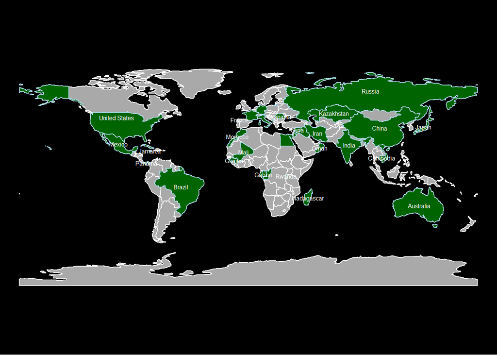